# R Notebook

## Running HINT-ATAC

```bash
cd /data/Austin/workdir/NC_Timecourse_Data/H1_TFAP2A_OE2_ATAC/
mkdir HINT

rgt-hint footprinting --atac-seq --paired-end --organism=hg38 --output-location=./HINT  --output-prefix=TFAP2A_1_HINT ./BAM/12793_10099_147158_HGHM3BGXK_H1_Ap2A_ATAC1_AGGCAGAA_toGRCh38_sorted_nodups.bam ./Peaks/12793_10099_147158_HGHM3BGXK_H1_Ap2A_ATAC1_AGGCAGAA_toGRCh38_sorted_nodups.bam_peaks.narrowPeak

rgt-hint footprinting --atac-seq --paired-end --organism=hg38 --output-location=./HINT  --output-prefix=TFAP2A_2_HINT ./BAM/12793_10099_147159_HGHM3BGXK_H1_Ap2A_ATAC2_TCCTGAGC_toGRCh38_sorted_nodups.bam ./Peaks/12793_10099_147159_HGHM3BGXK_H1_Ap2A_ATAC2_TCCTGAGC_toGRCh38_sorted_nodups.bam_peaks.narrowPeak

rgt-hint footprinting --atac-seq --paired-end --organism=hg38 --output-location=./HINT  --output-prefix=GFP_1_HINT ./BAM/12793_10099_147156_HGHM3BGXK_H1_GFP_ATAC1_TAAGGCGA_toGRCh38_sorted_nodups.bam ./Peaks/12793_10099_147156_HGHM3BGXK_H1_GFP_ATAC1_TAAGGCGA_toGRCh38_sorted_nodups.bam_peaks.narrowPeak

rgt-hint footprinting --atac-seq --paired-end --organism=hg38 --output-location=./HINT  --output-prefix=GFP_2_HINT ./BAM/12793_10099_147157_HGHM3BGXK_H1_GFP_ATAC2_CGTACTAG_toGRCh38_sorted_nodups.bam ./Peaks/12793_10099_147157_HGHM3BGXK_H1_GFP_ATAC2_CGTACTAG_toGRCh38_sorted_nodups.bam_peaks.narrowPeak

# Compare outputs
rgt-motifanalysis matching --organism=hg38 --motif-dbs ~/rgtdata/motifs/JASPAR2020-Vert-NonRedundant --rmdup --input-files ./HINT/TFAP2A_1_HINT.bed ./HINT/TFAP2A_2_HINT.bed ./HINT/GFP_1_HINT.bed ./HINT/GFP_2_HINT.bed
```

Test TFAP2A-OE against GFP-OE

```bash
rgt-hint differential --organism=hg38 --bc --nc 62 \
--mpbs-files=./match/TFAP2A_1_HINT_mpbs.bed,./match/TFAP2A_2_HINT_mpbs.bed,./match/GFP_1_HINT_mpbs.bed,./match/GFP_2_HINT_mpbs.bed --conditions=TFAP2A_OE,TFAP2A_OE,GFP_OE,GFP_OE --reads-files=./BAM/12793_10099_147158_HGHM3BGXK_H1_Ap2A_ATAC1_AGGCAGAA_toGRCh38_sorted_nodups.bam,./BAM/12793_10099_147159_HGHM3BGXK_H1_Ap2A_ATAC2_TCCTGAGC_toGRCh38_sorted_nodups.bam,./BAM/12793_10099_147156_HGHM3BGXK_H1_GFP_ATAC1_TAAGGCGA_toGRCh38_sorted_nodups.bam,./BAM/12793_10099_147157_HGHM3BGXK_H1_GFP_ATAC2_CGTACTAG_toGRCh38_sorted_nodups.bam --output-location=TFAP2A_OE_VS_GFP_Enriched_Footprinting_2
```

```bash
cd /data/Austin/workdir/NC_Timecourse_Data/H1_TFAP2A_OE2_ATAC/
mkdir HINT_TFAP2A_OE2_Enriched

rgt-hint footprinting --atac-seq --paired-end --organism=hg38 --output-location=./HINT_TFAP2A_OE2_Enriched  --output-prefix=TFAP2A_1_HINT_TFAP2A_OE2_Enriched ./BAM/12793_10099_147158_HGHM3BGXK_H1_Ap2A_ATAC1_AGGCAGAA_toGRCh38_sorted_nodups.bam ~/local_git/NC_Timecourse/ATAC-Seq/Human_ESC_iNC/Exports/TFAP2A_OE_Enriched_Peaks.bed

rgt-hint footprinting --atac-seq --paired-end --organism=hg38 --output-location=./HINT_TFAP2A_OE2_Enriched  --output-prefix=TFAP2A_2_HINT_TFAP2A_OE2_Enriched ./BAM/12793_10099_147159_HGHM3BGXK_H1_Ap2A_ATAC2_TCCTGAGC_toGRCh38_sorted_nodups.bam ~/local_git/NC_Timecourse/ATAC-Seq/Human_ESC_iNC/Exports/TFAP2A_OE_Enriched_Peaks.bed

rgt-hint footprinting --atac-seq --paired-end --organism=hg38 --output-location=./HINT_TFAP2A_OE2_Enriched  --output-prefix=GFP_1_HINT_TFAP2A_OE2_Enriched ./BAM/12793_10099_147156_HGHM3BGXK_H1_GFP_ATAC1_TAAGGCGA_toGRCh38_sorted_nodups.bam ~/local_git/NC_Timecourse/ATAC-Seq/Human_ESC_iNC/Exports/TFAP2A_OE_Enriched_Peaks.bed

rgt-hint footprinting --atac-seq --paired-end --organism=hg38 --output-location=./HINT_TFAP2A_OE2_Enriched  --output-prefix=GFP_2_HINT_TFAP2A_OE2_Enriched ./BAM/12793_10099_147157_HGHM3BGXK_H1_GFP_ATAC2_CGTACTAG_toGRCh38_sorted_nodups.bam ~/local_git/NC_Timecourse/ATAC-Seq/Human_ESC_iNC/Exports/TFAP2A_OE_Enriched_Peaks.bed

rgt-motifanalysis matching --organism=hg38 --motif-dbs ~/rgtdata/motifs/JASPAR2020-Vert-NonRedundant --rmdup --input-files  ./HINT_TFAP2A_OE2_Enriched/TFAP2A_1_HINT_TFAP2A_OE2_Enriched.bed ./HINT_TFAP2A_OE2_Enriched/TFAP2A_2_HINT_TFAP2A_OE2_Enriched.bed ./HINT_TFAP2A_OE2_Enriched/GFP_1_HINT_TFAP2A_OE2_Enriched.bed ./HINT_TFAP2A_OE2_Enriched/GFP_2_HINT_TFAP2A_OE2_Enriched.bed

rgt-hint differential --organism=hg38 --bc --nc 62 \
--mpbs-files=./match/TFAP2A_1_HINT_TFAP2A_OE2_Enriched_mpbs.bed,./match/TFAP2A_2_HINT_TFAP2A_OE2_Enriched_mpbs.bed,./match/GFP_1_HINT_TFAP2A_OE2_Enriched_mpbs.bed,./match/GFP_2_HINT_TFAP2A_OE2_Enriched_mpbs.bed --conditions=TFAP2A_OE,TFAP2A_OE,GFP_OE,GFP_OE --reads-files=./BAM/12793_10099_147158_HGHM3BGXK_H1_Ap2A_ATAC1_AGGCAGAA_toGRCh38_sorted_nodups.bam,./BAM/12793_10099_147159_HGHM3BGXK_H1_Ap2A_ATAC2_TCCTGAGC_toGRCh38_sorted_nodups.bam,./BAM/12793_10099_147156_HGHM3BGXK_H1_GFP_ATAC1_TAAGGCGA_toGRCh38_sorted_nodups.bam,./BAM/12793_10099_147157_HGHM3BGXK_H1_GFP_ATAC2_CGTACTAG_toGRCh38_sorted_nodups.bam --output-location=TFAP2A_OE_VS_GFP_Enriched_Footprinting
```

```r
differential_statistics2 <- read_delim("/data/Austin/workdir/NC_Timecourse_Data/H1_TFAP2A_OE2_ATAC/TFAP2A_OE_VS_GFP_Enriched_Footprinting_2/differential_statistics.txt",
    delim = "\t", escape_double = FALSE,
    trim_ws = TRUE)
```

```
* Protection_Score_TFAP2A_OE -> Protection_Score_TFAP2A_OE...3
* Protection_Score_TFAP2A_OE -> Protection_Score_TFAP2A_OE...4
* Protection_Score_GFP_OE -> Protection_Score_GFP_OE...5
* Protection_Score_GFP_OE -> Protection_Score_GFP_OE...6
* TC_TFAP2A_OE -> TC_TFAP2A_OE...7
* ...
```

What is the overlap between the normal Sox2 binding and the ATAC peaks that increased in accessibility?

```r
summary(sox2_peaks_withdual %over% tfap2a_OE_peaks)
```

```
   Mode   FALSE    TRUE
logical     571       1
```

# SOX2 CUT&RUN Analysis in TFAP2A vs GFP OE In the 1_Sox2_Dimer_Timecourse doc

Pairwise comparison of samples with D0

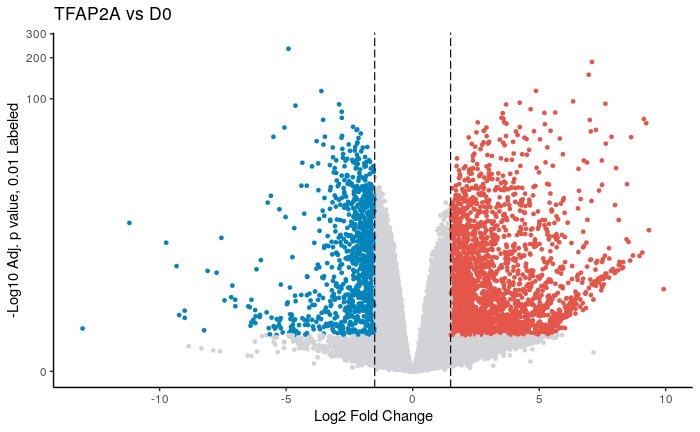

```r
ggsave(filename = "Exports/GFP_OE_vs_D0.png", height = 5, width = 5)
restest_TFAP2A_vs_D0 <- as.data.frame(results(dds2, contrast = c("Condition","AP2A_OE","D0"), parallel = TRUE))

restest_TFAP2A_vs_D0$Symbol <- mapIds(org.Hs.eg.db, keys = rownames(restest_TFAP2A_vs_D0), keytype = "ENSEMBL", column = "SYMBOL")
restest_TFAP2A_vs_D0 <- restest_TFAP2A_vs_D0 %>% mutate(threshold = ifelse(log2FoldChange >= 1.5 & padj < 0.05, "A", ifelse(log2FoldChange <= -1.5 & padj < 0.05, "B", "C")))

TFAP2A_vs_D0_g <- ggplot(data = restest_TFAP2A_vs_D0, aes(x = log2FoldChange, y = -log10(padj))) +
        geom_point(aes(color = threshold), size = 1, alpha = 1) +
        scale_color_manual(values = c("A" = "#e45649", "B" = "#0584bc", "C" = "#d3d2d6")) +
        geom_text_repel(data=subset(restest_TFAP2A_vs_D0, restest_TFAP2A_vs_D0$Symbol %in% GRN_Genes$Symbol), #& TF_Status=="Transcription Factor"),
                        aes(label = Symbol), box.padding = 0.2, segment.color = "#393a42", segment.size = 0.5, color = "#393a42") +
        ggtitle("TFAP2A vs D0") +
        #scale_x_continuous(limits = c(-6,6)) +
        geom_vline(xintercept = c(-1.5,1.5), linetype = "longdash", color = "black", size = 0.4) +
        theme_classic() +
        xlab("Log2 Fold Change") +
        ylab(paste0("-Log10 Adj. p value, 0.01 Labeled")) +
        theme(legend.position = "none") +
        scale_y_continuous(trans = "pseudo_log")
        # , axis.title = element_blank(),
        #      axis.text = element_blank(),
        #      axis.ticks = element_blank(),
        #      plot.title = element_blank()) #plot.title = element_text(hjust = 0.5))
TFAP2A_vs_D0_g
ggsave(filename = "Exports/TFAP2A_OE_vs_D0.png", height = 5, width = 5)
```

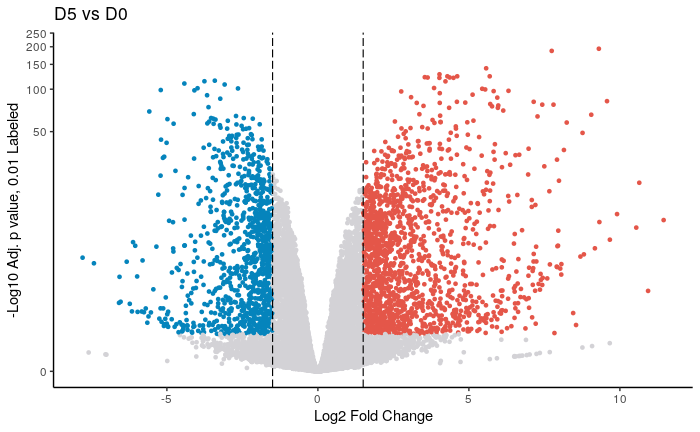

```r
#D5 vs D0
restest_D5_vs_D0 <- as.data.frame(results(dds2, contrast = c("Condition","D5","D0"), parallel = TRUE))

restest_D5_vs_D0$Symbol <- mapIds(org.Hs.eg.db, keys = rownames(restest_D5_vs_D0), keytype = "ENSEMBL", column = "SYMBOL")
restest_D5_vs_D0 <- restest_D5_vs_D0 %>% mutate(threshold = ifelse(log2FoldChange >= 1.5 & padj < 0.05, "A", ifelse(log2FoldChange <= -1.5 & padj < 0.05, "B", "C")))

D5_vs_D0_g <- ggplot(data = restest_D5_vs_D0, aes(x = log2FoldChange, y = -log10(padj))) +
        geom_point(aes(color = threshold), size = 1, alpha = 1) +
        scale_color_manual(values = c("A" = "#e45649", "B" = "#0584bc", "C" = "#d3d2d6")) +
        geom_text_repel(data=subset(restest_D5_vs_D0, restest_D5_vs_D0$Symbol %in% GRN_Genes$Symbol), #& TF_Status=="Transcription Factor"),
                        aes(label = Symbol), box.padding = 0.2, segment.color = "#393a42", segment.size = 0.5, color = "#393a42") +
        ggtitle("D5 vs D0") +
        #scale_x_continuous(limits = c(-6,6)) +
        geom_vline(xintercept = c(-1.5,1.5), linetype = "longdash", color = "black", size = 0.4) +
        theme_classic() +
        xlab("Log2 Fold Change") +
        ylab(paste0("-Log10 Adj. p value, 0.01 Labeled")) +
        theme(legend.position = "none") +
        scale_y_continuous(trans = "pseudo_log")
        # , axis.title = element_blank(),
        #      axis.text = element_blank(),
        #      axis.ticks = element_blank(),
        #      plot.title = element_blank()) #plot.title = element_text(hjust = 0.5))
D5_vs_D0_g
ggsave(filename = "Exports/D5_vs_D0.png", height = 5, width = 5)
```

Let’s visualize the delta in Log2FC for all GRN genes for each comparison.

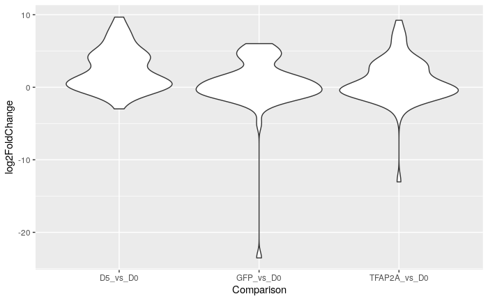

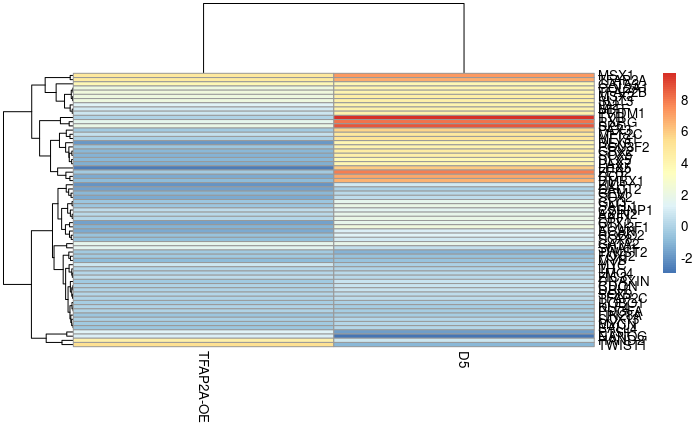

Let’s do bar graphs for a set of our favorite GRN genes

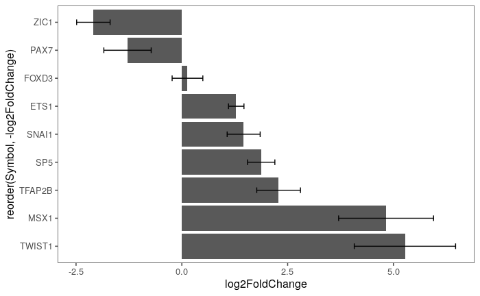